# BioStats Exam 1

Austin Gratton

October 20, 2018

## Question 1

Summary statistics and plots after removing missing data.

```r
df = read.csv('https://raw.githubusercontent.com/AustinGratton/STT520/master/Exam1data-1.csv')
df = df[which(is.na(df[,2]) == FALSE),]

info = matrix(c(mean(df$duration),sd(df$duration), mean(df$age),sd(df$age)), nrow = 2)
colnames(info) = c('Mean', 'SD'); rownames(info) = c('Duration','Age')
info
```

```
##              Mean      SD
## Duration 12.68000 41.2400
## Age      17.67701 20.1024
```

We observe the average and standard deviation among the duration of school closings and the age of the universities.

```r
table(df$public)
```

```
##
##  0  1
##  7 18
```

We have 18 public universities and 7 private universities.

```r
table(df$coastal)
```

```
##
##  0  1
##  6 19
```

We have 19 coastal universities and 6 inland.

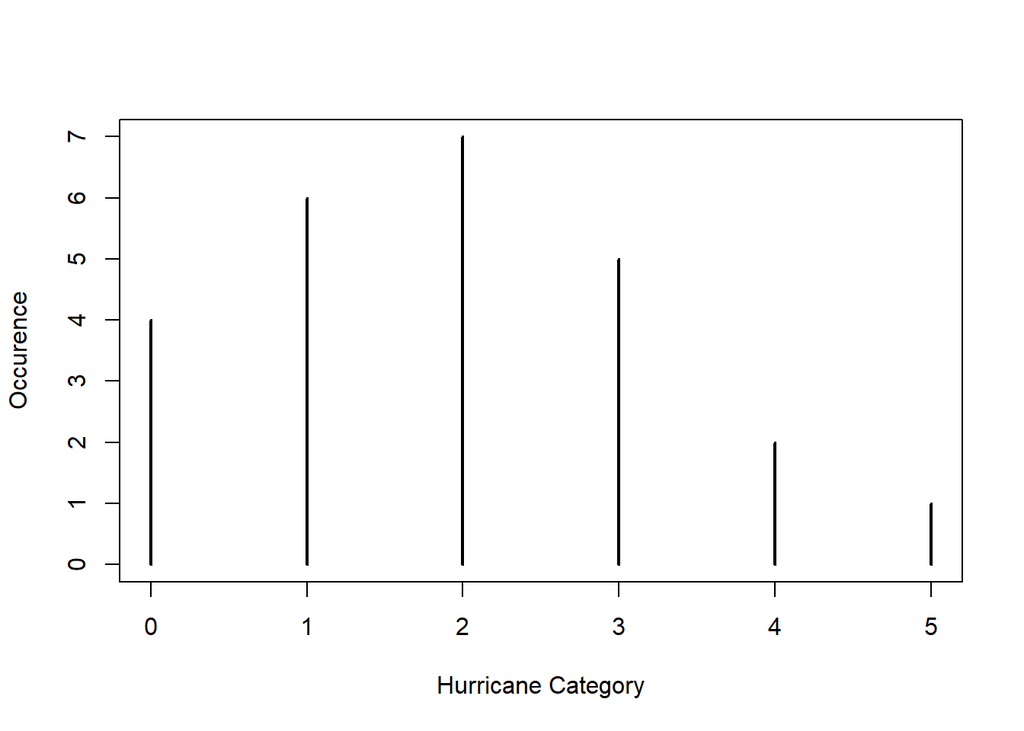

```r
plot(table(df$category), ylab = 'Occurence', xlab = 'Hurricane Category')
```

We see the breakdown of what category the hurricane was when impacting the universities.

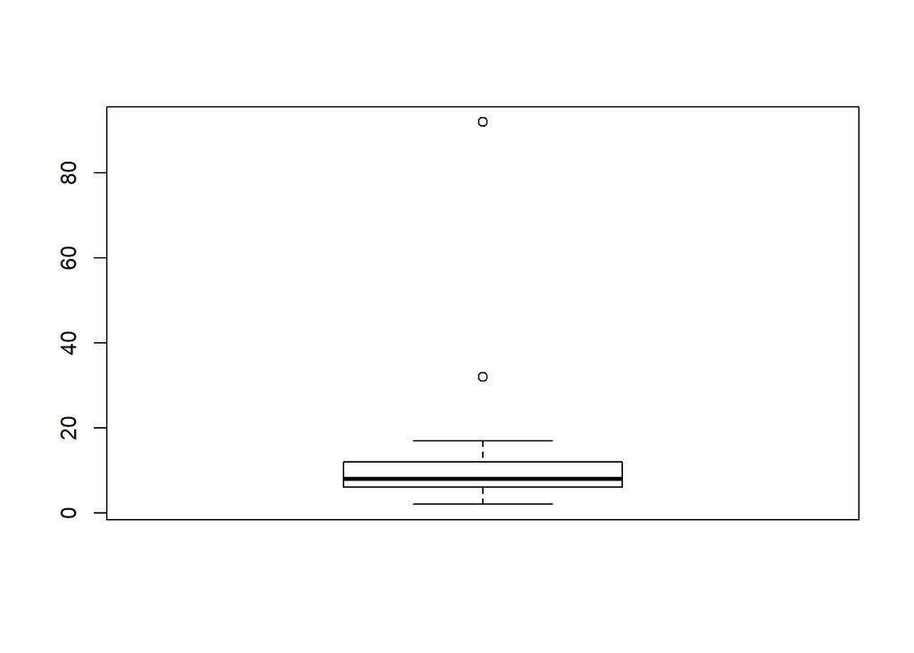

```r
boxplot(df$duration)
```

We observe most universities were closed from 2-20 days, however from the box plot we notice two potential outliers we will need to be aware of during analysis.

## Question 2

```r
mod = lm(df$duration ~ factor(df$public))
summary(mod)
```

```
##
## Call:
## lm(formula = df$duration ~ factor(df$public))
##
## Residuals:
##     Min      1Q  Median      3Q     Max
## -14.857  -8.278  -3.278   1.722  73.143
##
## Coefficients:
##                    Estimate Std. Error t value Pr(>|t|)
## (Intercept)          18.857      6.654   2.834  0.00941 **
## factor(df$public)1   -8.579      7.842  -1.094  0.28526
## ---
## Signif. codes:  0 '***' 0.001 '**' 0.01 '*' 0.05 '.' 0.1 ' ' 1
##
## Residual standard error: 17.6 on 23 degrees of freedom
## Multiple R-squared:  0.04947,    Adjusted R-squared:  0.008139
## F-statistic: 1.197 on 1 and 23 DF,  p-value: 0.2853
```

Immediately we do not see an affect on duration based on public vs. private schools. However we want to look at the summary plots to make sure our model is reliable.

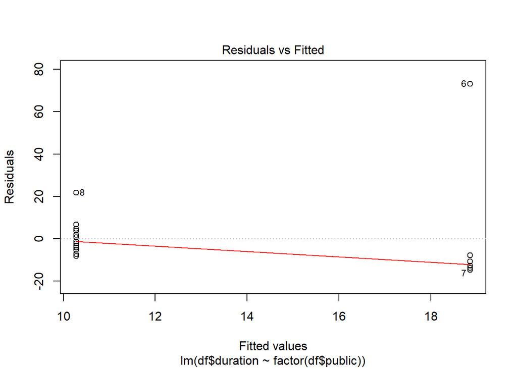

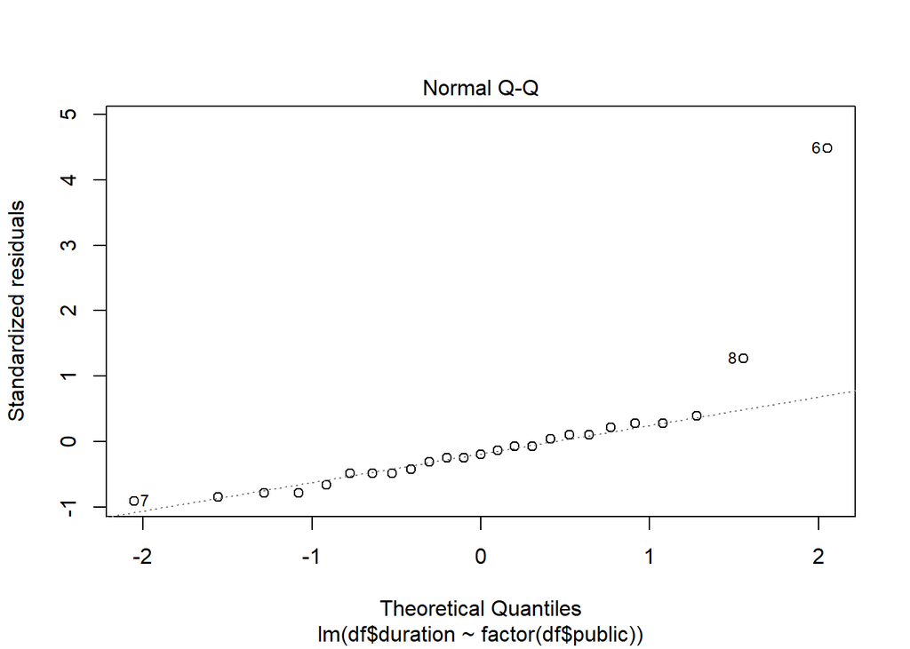

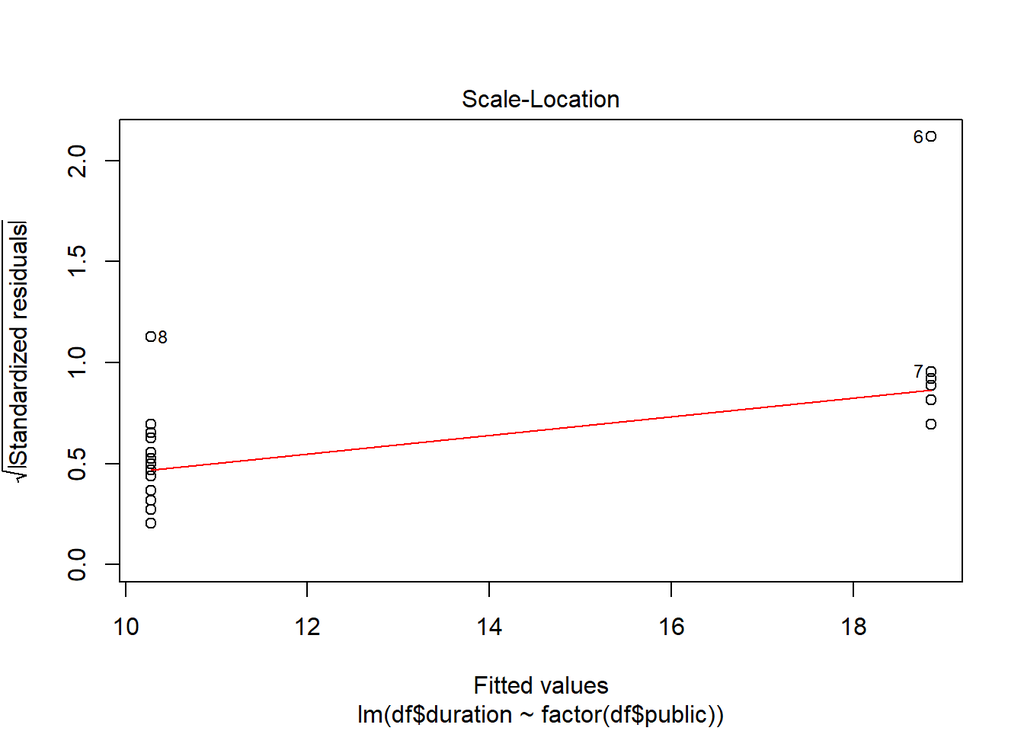

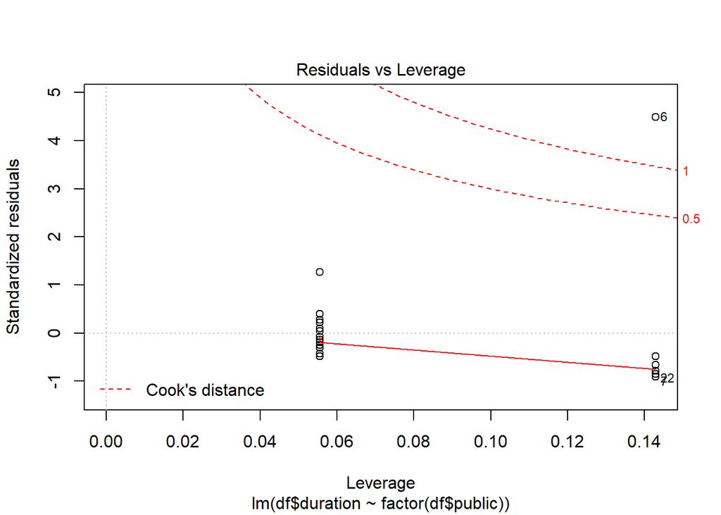

```r
plot(mod)
```

We notice two points in all four summary plots appearing as outliers, with one of them being outside of Cook’s distance. We should re-run the linear model with these two points removed and check the plots again.

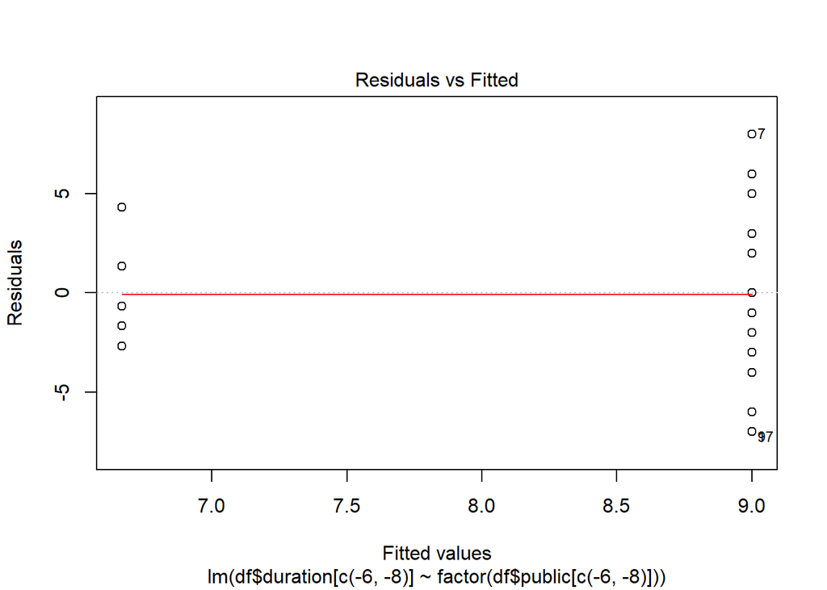

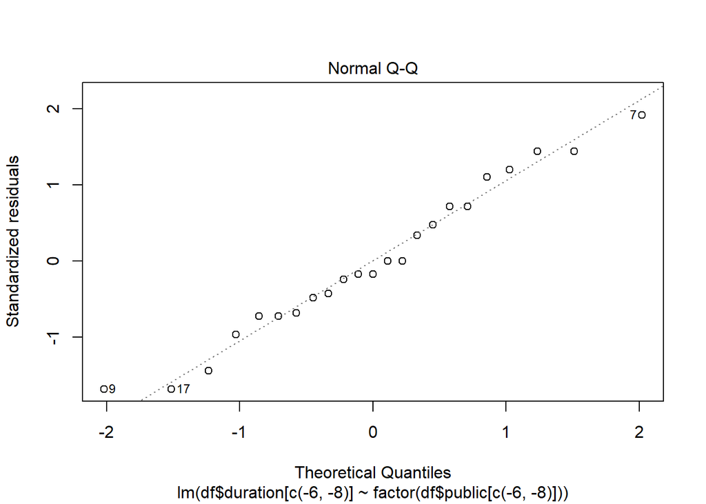

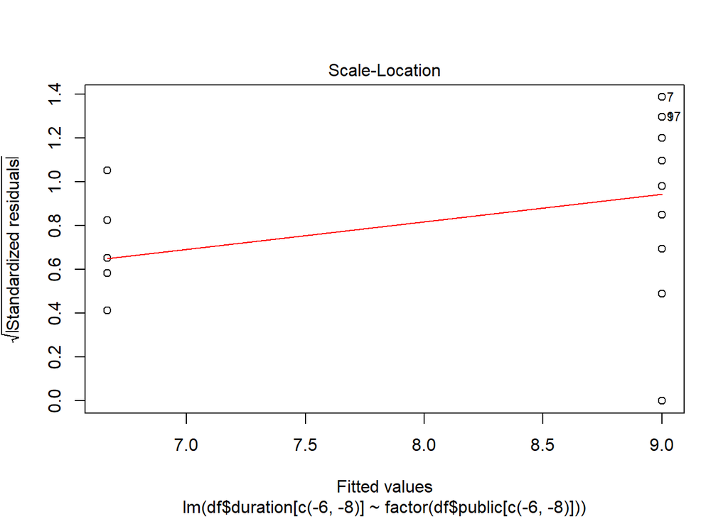

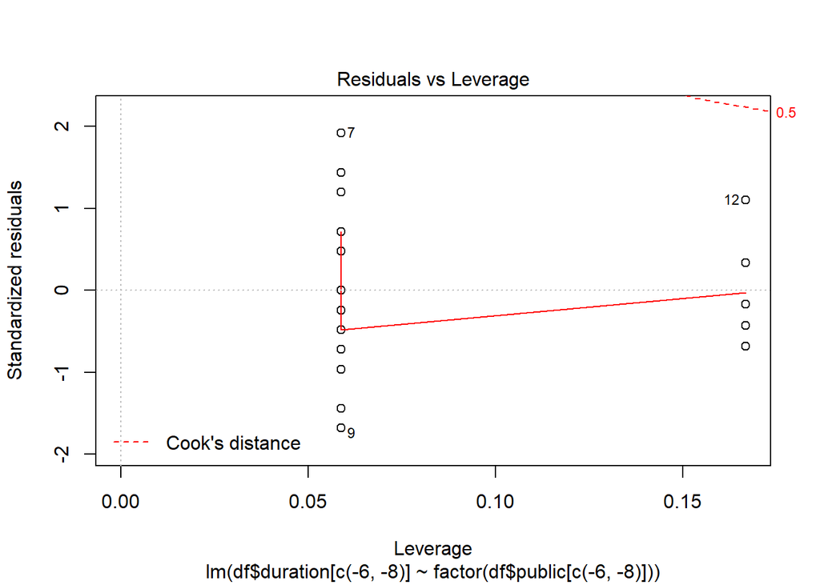

```r
mod2 = lm(df$duration[c(-6,-8)] ~ factor(df$public[c(-6,-8)]))
plot(mod2)
```

With the two suspected outliers removed, we do not have any points outside of Cook’s distance, and based on the Q-Q plot we can reasonably assume normality for the sake of this model. Now we want to look at the linear model to determine the affect of public vs. private.

```r
summary(mod2)
```

```
##
## Call:
## lm(formula = df$duration[c(-6, -8)] ~ factor(df$public[c(-6,
##     -8)]))
##
## Residuals:
##     Min      1Q  Median      3Q     Max
## -7.0000 -2.8333 -0.6667  3.0000  8.0000
##
## Coefficients:
##                               Estimate Std. Error t value Pr(>|t|)
## (Intercept)                      6.667      1.753   3.802  0.00104 **
## factor(df$public[c(-6, -8)])1    2.333      2.039   1.144  0.26544
## ---
## Signif. codes:  0 '***' 0.001 '**' 0.01 '*' 0.05 '.' 0.1 ' ' 1
##
## Residual standard error: 4.295 on 21 degrees of freedom
## Multiple R-squared:  0.05868,    Adjusted R-squared:  0.01385
## F-statistic: 1.309 on 1 and 21 DF,  p-value: 0.2654
```

With the outliers removed we still conclude that there is no significant effect of public vs. private university on the duration of the closing.

## Question 3

```r
u.priv = mean(df$duration[df$public == 0])
u.pub = mean(df$duration[df$public == 1])
sigma = sd(df$duration)
delta = (u.priv - u.pub)/sigma
pwr = qnorm(.8)
sig = qnorm(1-(.05/2))
N = (2*(sig + pwr)^2)/delta^2
N
```

```
## [1] 66.64153
```

## Question 4

#### Category/Public

```r
df$categorydi = ifelse(df$category < 1, c(0), c(1))
cat.tab1 = table(df$categorydi, df$public)
sens1 = cat.tab1[2,2]/sum(cat.tab1[,2])
spec1 = cat.tab1[1,1]/sum(cat.tab1[,1])

df$categorydi = ifelse(df$category < 2, c(0), c(1))
cat.tab2 = table(df$categorydi, df$public)
sens2 = cat.tab2[2,2]/sum(cat.tab2[,2])
spec2 = cat.tab2[1,1]/sum(cat.tab2[,1])

df$categorydi = ifelse(df$category < 3, c(0), c(1))
cat.tab3 = table(df$categorydi, df$public)
sens3 = cat.tab3[2,2]/sum(cat.tab3[,2])
spec3 = cat.tab3[1,1]/sum(cat.tab3[,1])

df$categorydi = ifelse(df$category < 4, c(0), c(1))
cat.tab4 = table(df$categorydi, df$public)
sens4 = cat.tab4[2,2]/sum(cat.tab4[,2])
spec4 = cat.tab4[1,1]/sum(cat.tab4[,1])

df$categorydi = ifelse(df$category < 5, c(0), c(1))
cat.tab5 = table(df$categorydi, df$public)
sens5 = cat.tab5[2,2]/sum(cat.tab5[,2])
spec5 = cat.tab5[1,1]/sum(cat.tab5[,1])

mat = matrix(c(sens1, spec1, sens2, spec2, sens3, spec3, sens4, spec4, sens5, spec5), ncol = 2, byrow = TRUE)
colnames(mat) = c('sensitivity', 'specifictiy')
mat
```

```
##      sensitivity specifictiy
## [1,]  0.83333333   0.1428571
## [2,]  0.61111111   0.4285714
## [3,]  0.27777778   0.5714286
## [4,]  0.05555556   0.7142857
## [5,]  0.00000000   0.8571429
```

```r
sens2; spec2;
```

```
## [1] 0.6111111
```

```
## [1] 0.4285714
```

We determine `2` to be the ideal cutoff of category based on the sensitivity and specificity table. With a sensitivity of 0.6111111 and specificity of 0.4285714.

```r
library(pROC)
```

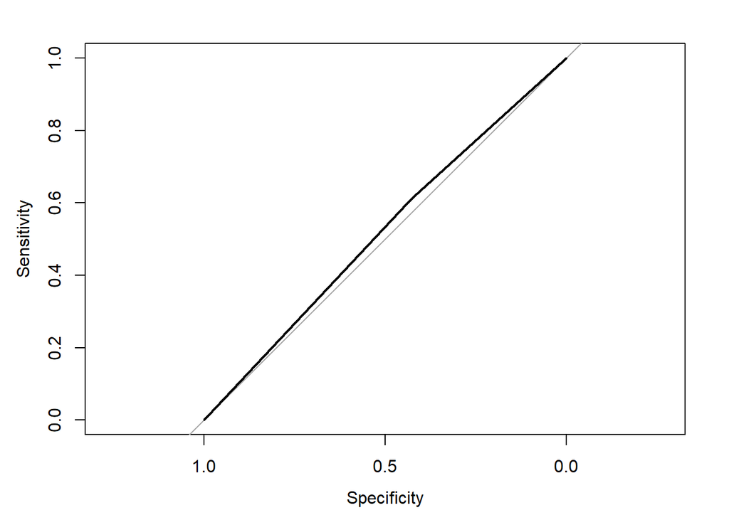

```r
df$categorydi = ifelse(df$category < 2, c(0), c(1))
roc_obj = roc(df$public, df$categorydi)
A = auc(roc_obj)
plot(roc_obj)
```

From the ROC curve and an AUC = 0.5198413 we can see there is likely no relationship between category and public because from the data it is essentially a coin flip when determining public from category.

#### Coastal/Public

```r
coa.tab = table(df$coastal,df$public)
sens = coa.tab[2,2]/sum(coa.tab[,2])
spec = coa.tab[1,1]/sum(coa.tab[,1])
```

We observe a sensitivity of 0.8888889 and a specificity of 0.5714286.

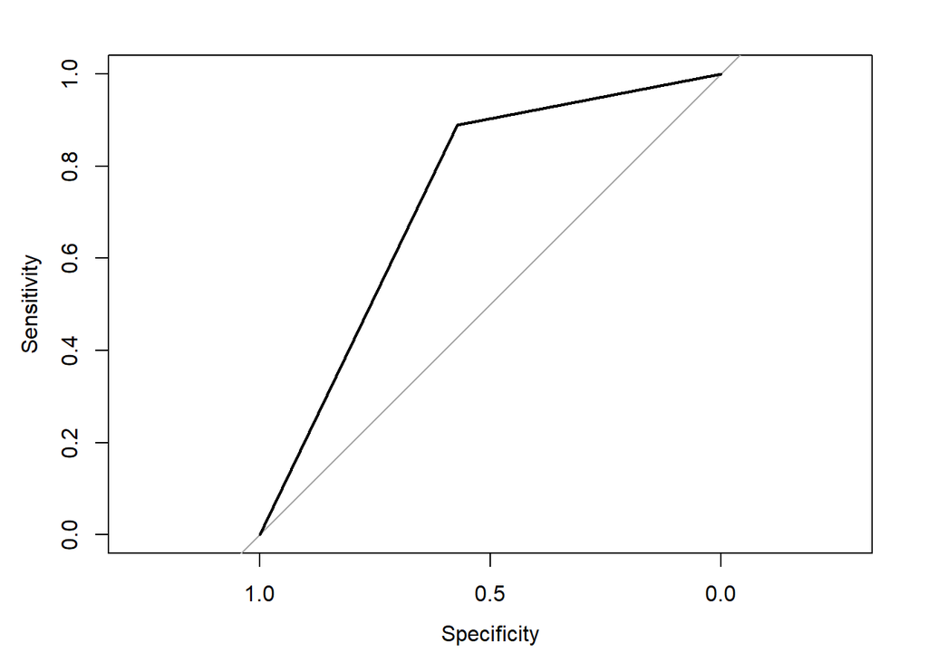

```r
roc_obj = roc(df$public, df$coastal)
A2 = auc(roc_obj)
plot(roc_obj)
```

From the ROC plot and AUC = 0.7301587 we see there is possible a relationship between coastal and public. However with the small sample size and low specificity we cannot conclude that this is a good indicator of a public university.

## Question 5

#### 5.a

```r
a = pnorm(14.5,11.5,3)-pnorm(8.5,11.5,3)
a
```

```
## [1] 0.6826895
```

There is a %68.27 chance that a university is closed between 8.5 and 14.5 days after a hurricane.

#### 5.b

```r
b = pnorm(10,11.5,3,lower.tail = FALSE)
b
```

```
## [1] 0.6914625
```

There is a %69.15 chance that a university is closed for more than 10 days.

#### 5.c

```r
c = pnorm(12,11.5,3)
c
```

```
## [1] 0.5661838
```

There is a %56.62 chance that a university is closed for less than 12 days.

## Question 6

```r
table(df$category, df$public)
```

```
##
##     0 1
##   0 1 3
##   1 2 4
##   2 1 6
##   3 1 4
##   4 1 1
##   5 1 0
```